# ESM204 HW4 Andrew, Qusai, Tor

Andrew Salvador, Qusai Bhaijeewala, & Tor Fibiger

5/25/2020

Build the functions, set variables t & T, everything else is given temp = temperature at year t K_t = fraction of economic activity retained at year t, if temperature is T(t) C_t = economic activity (“consumption”) at time t U_c = society’s utility from consumption discount rate r = delta + ng

### QUESTION 1: PLOTS

1. Plot temperature over time for no climate change (T = 0), modest climate change (T = 2), and with extreme climate change (T = 8).

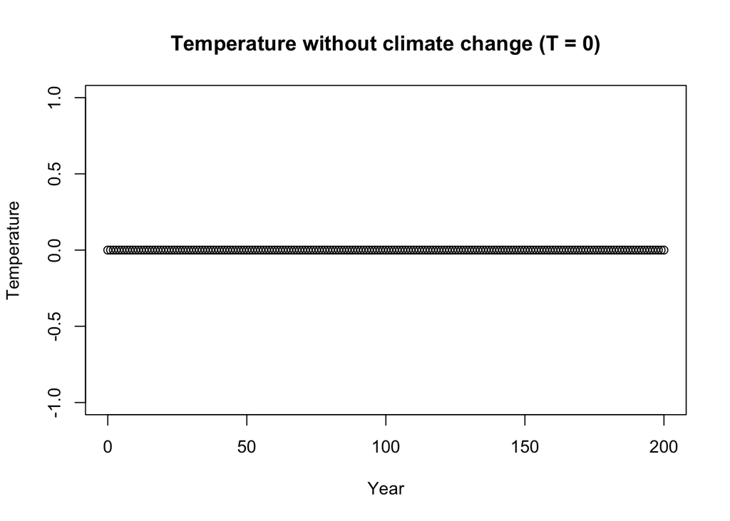

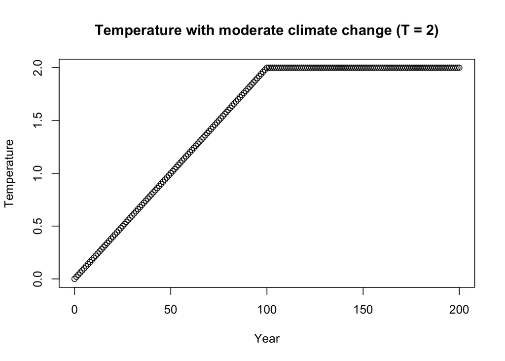

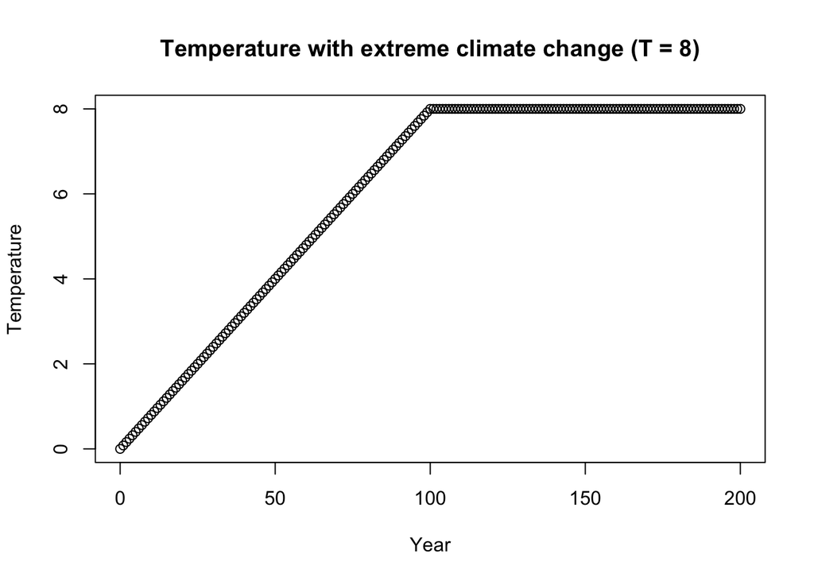

2. Plot consumption over time for no climate change, modest climate change, and extreme climate change.

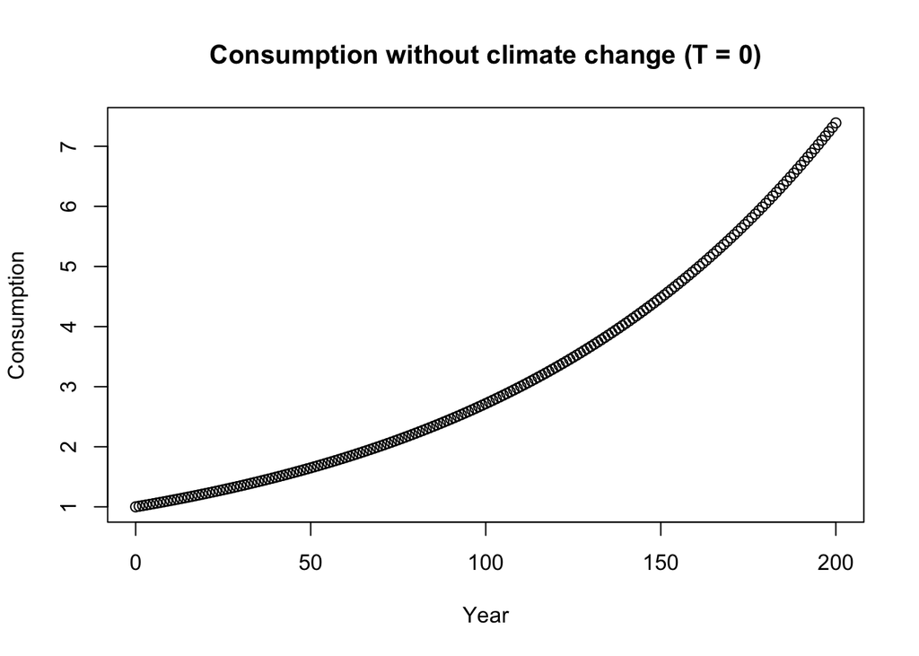

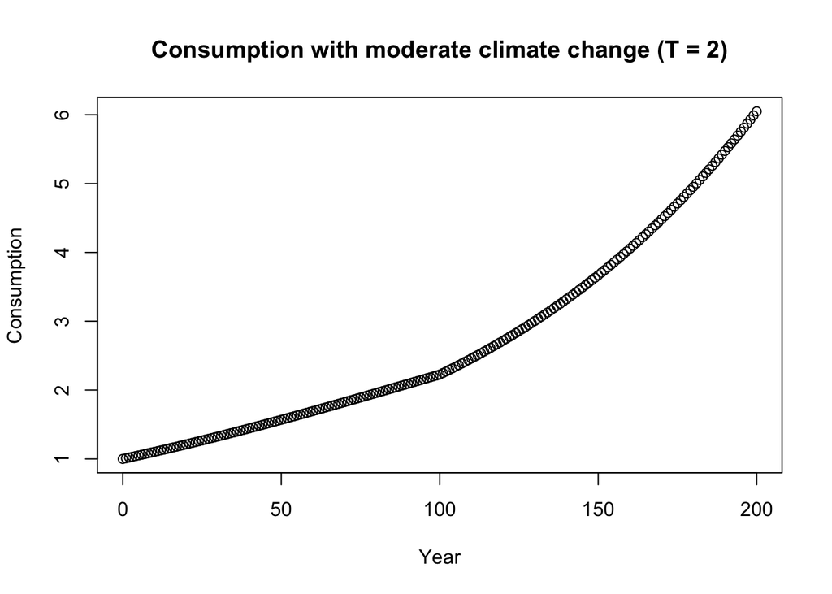

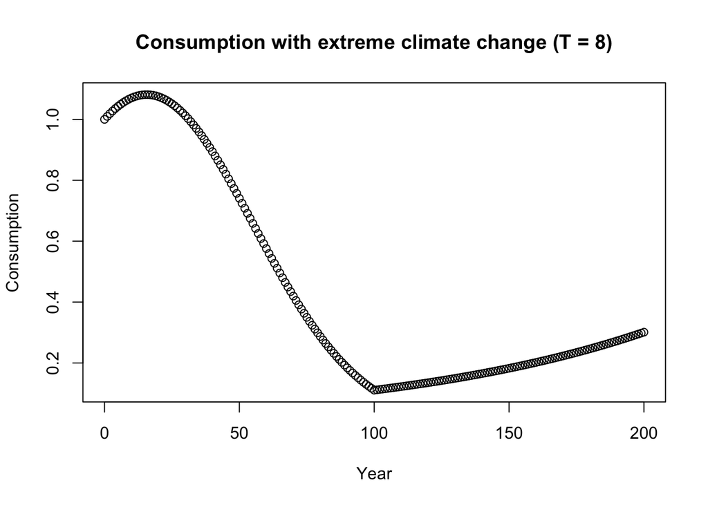

3. Plot undiscoutned utility over time for no climate change, modest climate change, and extreme climate change.

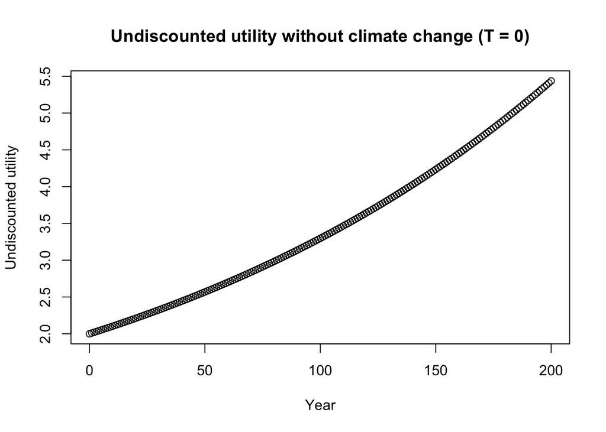

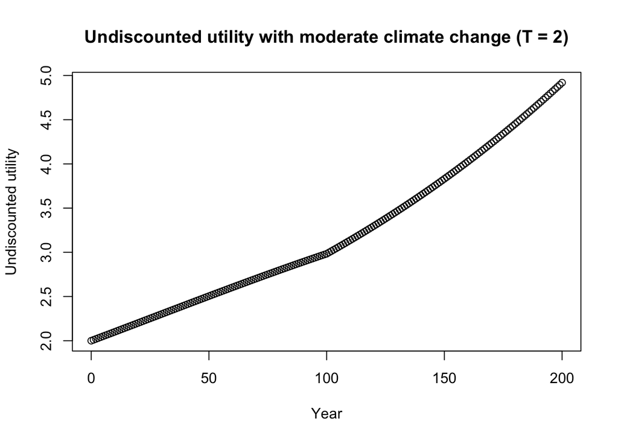

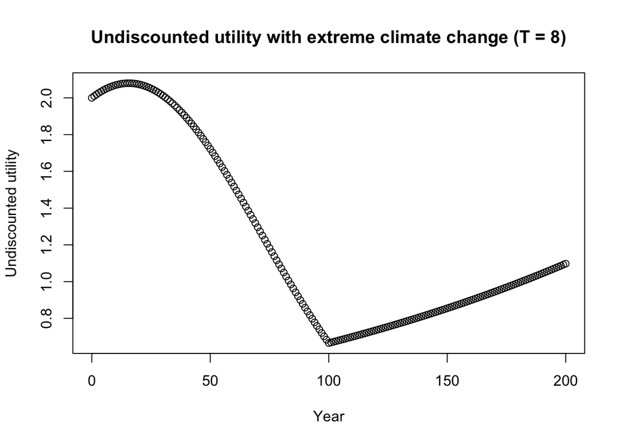

### QUESTION 2: ANALYSIS

#### (a) Suppose T = 4.4. What is the present value (i.e. discounted) utility over the next 200 years with climate change? What is the present value utility without climate change? What is the percentage loss in present value utility from climate change?

Net present value utility with climate change = 198.661219717316

Net present value utility without climate change = 255.273441757037

L = 22.18

#### (b) Now, show how sensitive your calculation of L is to the following parameters: T, g, n, and B. To do so, calculate the % change in L that arises from a 10% increase in each of these parameters.

**Sensitivity to T**

*With climate change sensitivity to T (10% increase of 4.4, new T = 4.84)*

New net present value utility with climate change = 189.421099192601

Without climate change sensitivity to T (10% increase of 0, new T = 0)

New net present value utility without climate change = 255.273441757037

*New L = 25.80*

```
A 10% increase in T caused L to increased from 22.18% to 25.80%, a 16.32% increase.
```

**Sensitivity to g**

*With climate change sensitivity to g (10% increase to 0.01, new g = 0.011)*

New net present value utility with climate change = 206.137459318153

New net present value utility without climate change = 266.277404501181

*New L = 22.59%*

```
A 10% increase in g caused L to increase minimally from 22.18% to 22.59%, a 1.85% increase.
```

**Sensitivity to n**

*With climate change sensitivity to n (10% increase to 0.5, new n = 0.55)*

New net present value utility with climate change = 217.796047447958

Without climate change sensitivity to n (10% increase to 0.5, new n = 0.55)

New net present value utility without climate change = 272.133835059214

*New L = 19.97%*

```
A 10% increase in n caused L to decrease from 22.18% to 19.97
```

**Sensitivity to B**

*With climate change sensitivity to B (10% increase to 0.05, new B = 0.055)*

New net present value utility with climate change = 194.164520791888

Without climate change sensitivity to B (10% increase to 0.05, new B = 0.055)

New net present value utility without = 255.273441757037

*New L = 23.94%*

```
A 10% increase in B caused L to increase from 22.18% to 23.94%
```

~~~~~~~~~~~~~~~~~~~~~~~~~~~~~~~~~~~~~~~~~~~~~~~~~~~~~~~~~~~~~~~~~~

#### (c) Back to the original parameters, suppose we could completely prevent climate change from ocurring (so T = 0 instead of T = 4.4) but doing so would require giving up a fraction omega of consumption every year for the next 200 years. What is the maximum value of omega society would be willing to endure every year to completely prevent climate change? Call this omegastar.

With climate change (T = 4.4), NPV utility = 198.66

Without climate change (T = 0), NPV utility = 255.27

[output not shown]

#### (d) Suppose we are uncertain about T, but it has the following probability distribution: T = 2 (probability 0.2), T = 4 (probability 0.5), T = 6 (probability 0.3). Calculate omegastar under uncertainty over T.

```
Omega* = 0.37 under uncertainty over T.
```